# SI 370 - Homework #4: Machine Learning 1

In this homework exercise you will apply the machine learning techniques we've covered so far: linear regression, machine learning pipelines, agglomerative clustering, k-means clustering, and t-SNE.

We will be using [graduate admissions data](https://www.kaggle.com/mohansacharya/graduate-admissions).

This is a fairly involved homework assignment and we *strongly* urge you to not leave this to the last minute. We suggest that you try to work on this assignment over several days.

```python
import numpy as np
import pandas as pd
import seaborn as sns
import matplotlib.pyplot as plt
from scipy import stats
```

```python
admit = pd.read_csv(
    'https://raw.githubusercontent.com/umsi-data-science/data/main/Admission_Predict.csv')
```

```python
admit.shape
```

```
(500, 8)
```

```python
admit.head()
```

|  | GRE Score | TOEFL Score | University Rating | SOP | LOR | CGPA | Research | Chance of Admit |
| --- | --- | --- | --- | --- | --- | --- | --- | --- |
| 0 | 337 | 118 | 4 | 4.5 | 4.5 | 9.65 | 1 | 0.92 |
| 1 | 324 | 107 | 4 | 4.0 | 4.5 | 8.87 | 1 | 0.76 |
| 2 | 316 | 104 | 3 | 3.0 | 3.5 | 8.00 | 1 | 0.72 |
| 3 | 322 | 110 | 3 | 3.5 | 2.5 | 8.67 | 1 | 0.80 |
| 4 | 314 | 103 | 2 | 2.0 | 3.0 | 8.21 | 0 | 0.65 |

## Task 1 (2 points):

Perform basic exploratory data analyses on the variables in this dataframe. Your work should include both numerical **and** graphical overviews of the data. The `multiplePlots` code might be helpful here.

```python
admit.describe()
```

|  | GRE Score | TOEFL Score | University Rating | SOP | LOR | CGPA | Research | Chance of Admit |
| --- | --- | --- | --- | --- | --- | --- | --- | --- |
| count | 500.000000 | 500.000000 | 500.000000 | 500.000000 | 500.00000 | 500.000000 | 500.000000 | 500.00000 |
| mean | 316.472000 | 107.192000 | 3.114000 | 3.374000 | 3.48400 | 8.576440 | 0.560000 | 0.72174 |
| std | 11.295148 | 6.081868 | 1.143512 | 0.991004 | 0.92545 | 0.604813 | 0.496884 | 0.14114 |
| min | 290.000000 | 92.000000 | 1.000000 | 1.000000 | 1.00000 | 6.800000 | 0.000000 | 0.34000 |
| 25% | 308.000000 | 103.000000 | 2.000000 | 2.500000 | 3.00000 | 8.127500 | 0.000000 | 0.63000 |
| 50% | 317.000000 | 107.000000 | 3.000000 | 3.500000 | 3.50000 | 8.560000 | 1.000000 | 0.72000 |
| 75% | 325.000000 | 112.000000 | 4.000000 | 4.000000 | 4.00000 | 9.040000 | 1.000000 | 0.82000 |
| max | 340.000000 | 120.000000 | 5.000000 | 5.000000 | 5.00000 | 9.920000 | 1.000000 | 0.97000 |

```python
admit.info()
```

```
<class 'pandas.core.frame.DataFrame'>
RangeIndex: 500 entries, 0 to 499
Data columns (total 8 columns):
 #   Column             Non-Null Count  Dtype
---  ------             --------------  -----
 0   GRE Score          500 non-null    int64
 1   TOEFL Score        500 non-null    int64
 2   University Rating  500 non-null    int64
 3   SOP                500 non-null    float64
 4   LOR                500 non-null    float64
 5   CGPA               500 non-null    float64
 6   Research           500 non-null    int64
 7   Chance of Admit    500 non-null    float64
dtypes: float64(4), int64(4)
memory usage: 31.4 KB
```

```python
def multiplePlots(series):

    fig, axs = plt.subplots(2, 2)
    plt.tight_layout(pad=0.4, w_pad=4, h_pad=1.0)

    # Histogram
    sns.distplot(series, ax=axs[0, 0])

    # Lag plot
    lag = series.copy()
    lag = np.array(lag[:-1])
    current = series[1:]
    ax = sns.regplot(current, lag, fit_reg=False, ax=axs[0, 1])
    ax.set_ylabel("y_i-1")
    ax.set_xlabel("y_i")

    # QQ plot
    qntls, xr = stats.probplot(series, fit=False)
    sns.regplot(xr, qntls, ax=axs[1, 0])

    # Run sequence
    ax = sns.regplot(np.arange(len(series)), series, ax=axs[1, 1])
    ax.set_ylabel("val")
    ax.set_xlabel("i")
```

[output not shown]

[output cut: 16 more lines]

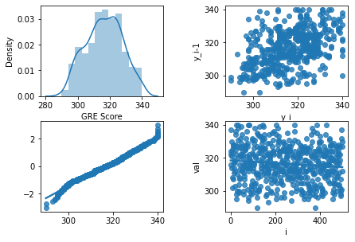

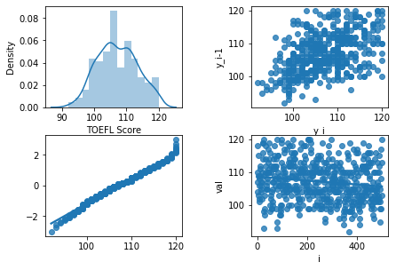

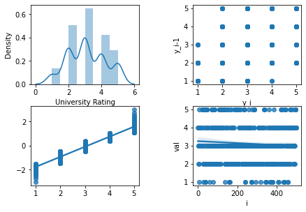

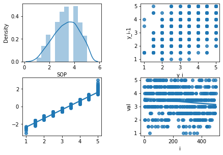

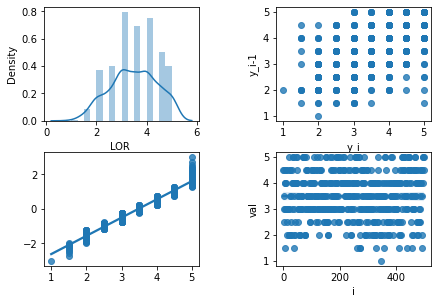

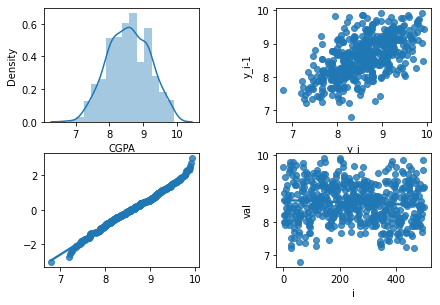

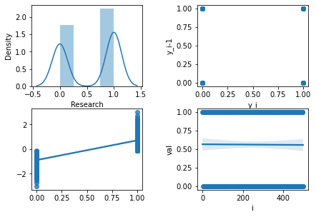

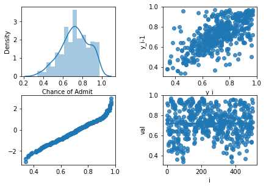

```python
for i in admit.columns:
    multiplePlots(admit[i])
```

## Task 2a (4 points):

Use scikit-learn to conduct a linear regression that models the chance of admission based on the other variables. Be sure to exclude "Serial No." as an explanatory variable. Be sure to pre-process the data appropriately. Assess how good your model is by reporting the root mean squared error (RMSE) using the test dataset from an 80-20 train-test-split of the original dataset.

```python
from sklearn.model_selection import train_test_split
from sklearn.linear_model import LinearRegression
from sklearn.metrics import mean_squared_error
from math import sqrt
```

```python
features = ['GRE Score', 'TOEFL Score', 'University Rating',
            'SOP', 'LOR ', 'CGPA', 'Research']

X = admit[features]
y = admit['Chance of Admit ']

X_train, X_test, y_train, y_test = train_test_split(
    X, y, test_size=0.2, random_state=42)

model = LinearRegression()

model.fit(X_train, y_train)

predictions = model.predict(X_test)

rmse = sqrt(mean_squared_error(y_test, predictions))
print("Root Mean Squared Error (RMSE):", rmse)
```

```
Root Mean Squared Error (RMSE): 0.060865880415783134
```

## Task 2b (1 point):

Based on your work in the previous task, what is the probability of admission for someone with a GRE score or 325, a TOEFL score of 108, a university rating of 3, an statement of purpose score of 3.0, a letter of recommendation score of 3.5, a high-school grade point average of 8.9, and who has research experience.

```python
input_metrics = [[325, 108, 3, 3.0, 3.5, 8.9, 1]]

predicted_admission_chance = model.predict(input_metrics)

predicted_admission_chance[0]
```

```
0.7922979757958464
```

There is a 79.23% chance of admission for someone with a GRE score or 325, a TOEFL score of 108, a university rating of 3, an statement of purpose score of 3.0, a letter of recommendation score of 3.5, a high-school grade point average of 8.9, and who has research experience.

## Task 3 (1 points):

Decide on a reasonable value for a threshold for admission. Pick a value that you would feel comfortable with if you wanted to know whether you were likely to be accepted into a graduate program. Create a new variable called "admitted" that is set to 1 if the chance of admission value is equal to or greater than your chosen threshold, 0 otherwise.

```python
threshold = 0.75

admit['admitted'] = admit['Chance of Admit '].apply(
    lambda x: 1 if x >= threshold else 0)
```

75% is a reasonable threshold as it is greater than 50% (a normal average), but not by a large amount. I used an apply function to create the new admit column based off this threshold.

## Task 4 (5 points):

Using your **test** dataset (i.e. approximately 80 rows) from above, conduct an agglomerative clustering analysis using average linkage based on PCA projections of the original data onto 2 dimensions (remember to scale your data before doing the PCA). Report the percentage of variance retained in the first two principal components.

Do not use the chance of admission column or the "admitted" variable you created in the previous step in your input data.

Create a dendrogram, pick an appropriate "cut line" and comment on the composition of each of the resulting clusters. Comment on the degree to which the clusters correspond to admission probabilities (note: you may find it helpful to examine the values of "admitted").

```python
from sklearn.pipeline import Pipeline
from sklearn.preprocessing import StandardScaler
from sklearn.decomposition import PCA

from sklearn.cluster import AgglomerativeClustering
from sklearn.impute import SimpleImputer
from scipy.cluster.hierarchy import dendrogram
```

```python
pipe = Pipeline([
    ('fillna', SimpleImputer(strategy='constant', fill_value=1)),
    ('scale', StandardScaler()),
    ('pca', PCA(n_components=2, random_state=42)),
    ('agglomerative', AgglomerativeClustering(
        affinity='euclidean', linkage='average', n_clusters=9))
])

ypred = pipe.fit_predict(X_test)
```

```python
pca = pipe.named_steps["pca"]
explained_variance_ratios = pca.explained_variance_ratio_[:2]
total = sum(explained_variance_ratios)
total
```

```
0.7965960081881768
```

```python
pipe["pca"].explained_variance_ratio_
```

```
array([0.69885961, 0.0977364 ])
```

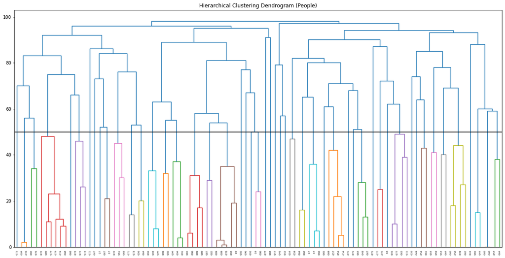

```python
def plot_dendrogram(model, **kwargs):

    # Children of hierarchical clustering
    children = model.children_

    # Distances between each pair of children
    # Since we don't have this information, we can use a uniform one for plotting
    distance = np.arange(children.shape[0])

    # The number of observations contained in each cluster level
    no_of_observations = np.arange(2, children.shape[0]+2)

    # Create linkage matrix and then plot the dendrogram
    linkage_matrix = np.column_stack(
        [children, distance, no_of_observations]).astype(float)

    # Plot the corresponding dendrogram
    dendrogram(linkage_matrix, **kwargs)
    # Draw a horizontal line at our cutoff
    color_threshold = kwargs.pop('color_threshold', None)
    plt.axhline(y=color_threshold, c='k')


plt.figure(figsize=(20, 10))
plt.title('Hierarchical Clustering Dendrogram (People)')
plot_dendrogram(pipe.named_steps.agglomerative,
                labels=y_test.values, color_threshold=50)
plt.xticks(rotation=90)
# and save the figure to a PDF file
plt.savefig('dendrogram.pdf')
```

## Task 5 (4 points):

Conduct a k-means clustering of the admissions data. Pre-process the data using a 2-dimensional PCA (remember to scale your data before doing the PCA). Again, do not use the chance of admission or the "admitted" variable you created earlier. Use the average silhouette score to determine the optimal number of clusters and show the silhouette plot for the optimal number of clusters.

```python
from sklearn.cluster import KMeans
from sklearn.metrics import silhouette_score, silhouette_samples
import matplotlib.cm as cm
```

```python
pipe0 = Pipeline([
    ('fillna', SimpleImputer(strategy='constant', fill_value=1)),
    ('scale', StandardScaler()),
    ('pca', PCA(n_components=2, random_state=42)),
])
```

```python
pipe1 = Pipeline([
    ('preprocessing', pipe0),
    ('kmeans', KMeans(n_clusters=2, init='k-means++', random_state=42)),
])
```

```python
Xformed = pipe0.fit_transform(X.values)
```

```
For n_clusters = 2 The average silhouette_score is : 0.497690437414033
For n_clusters = 3 The average silhouette_score is : 0.41143535077744364
For n_clusters = 4 The average silhouette_score is : 0.4292397566910888
```

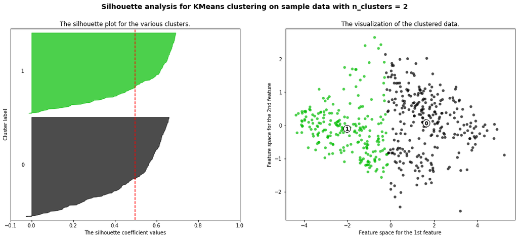

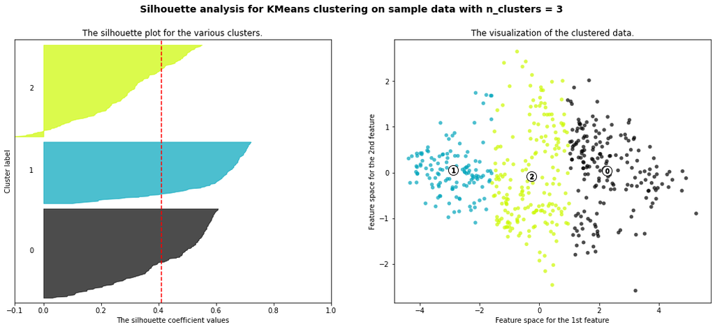

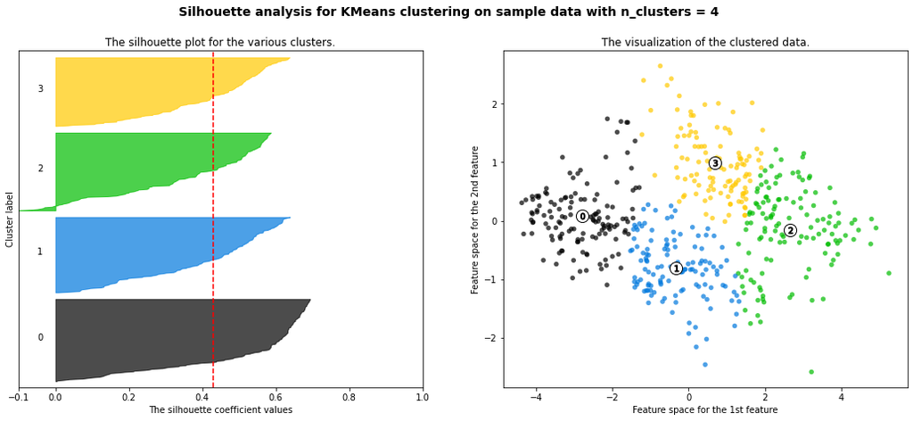

```python
range_n_clusters = [2, 3, 4]
label_points = False
for n_clusters in range_n_clusters:
    # Create a subplot with 1 row and 2 columns
    fig, (ax1, ax2) = plt.subplots(1, 2)
    fig.set_size_inches(18, 7)

    # The 1st subplot is the silhouette plot
    # The silhouette coefficient can range from -1, 1 but in this example all
    # lie within [-0.1, 1]
    ax1.set_xlim([-0.1, 1])
    # The (n_clusters+1)*10 is for inserting blank space between silhouette
    # plots of individual clusters, to demarcate them clearly.
    ax1.set_ylim([0, len(Xformed) + (n_clusters + 1) * 10])

    # Initialize the clusterer with n_clusters value and a random generator
    # seed of 42 for reproducibility.
    # clusterer = KMeans(n_clusters=n_clusters, random_state=42)
    # cluster_labels = clusterer.fit_predict(Xformed)

    pipe1.named_steps.kmeans.set_params(n_clusters=n_clusters, random_state=42)
    clusterer = pipe1.named_steps.kmeans
    cluster_labels = pipe1.fit_predict(X)
    cluster_labels = KMeans(n_clusters=n_clusters,
                            random_state=42).fit_predict(Xformed)
    # The silhouette_score gives the average value for all the samples.
    # This gives a perspective into the density and separation of the formed
    # clusters
    silhouette_avg = silhouette_score(Xformed, cluster_labels)
    print("For n_clusters =", n_clusters,
          "The average silhouette_score is :", silhouette_avg)

    # Compute the silhouette scores for each sample
    sample_silhouette_values = silhouette_samples(Xformed, cluster_labels)

    y_lower = 10
    for i in range(n_clusters):
        # Aggregate the silhouette scores for samples belonging to
        # cluster i, and sort them
        ith_cluster_silhouette_values = sample_silhouette_values[cluster_labels == i]

        ith_cluster_silhouette_values.sort()

        size_cluster_i = ith_cluster_silhouette_values.shape[0]
        y_upper = y_lower + size_cluster_i

        color = cm.nipy_spectral(float(i) / n_clusters)
        ax1.fill_betweenx(np.arange(y_lower, y_upper),
                          0, ith_cluster_silhouette_values,
                          facecolor=color, edgecolor=color, alpha=0.7)

        # Label the silhouette plots with their cluster numbers at the middle
        ax1.text(-0.05, y_lower + 0.5 * size_cluster_i, str(i))

        # Compute the new y_lower for next plot
        y_lower = y_upper + 10  # 10 for the 0 samples

    ax1.set_title("The silhouette plot for the various clusters.")
    ax1.set_xlabel("The silhouette coefficient values")
    ax1.set_ylabel("Cluster label")

    # The vertical line for average silhouette score of all the values
    ax1.axvline(x=silhouette_avg, color="red", linestyle="--")

    ax1.set_yticks([])  # Clear the yaxis labels / ticks
    ax1.set_xticks([-0.1, 0, 0.2, 0.4, 0.6, 0.8, 1])

    # 2nd Plot showing the actual clusters formed
    colors = cm.nipy_spectral(cluster_labels.astype(float) / n_clusters)
    ax2.scatter(Xformed[:, 0], Xformed[:, 1], marker='o', s=30, lw=0, alpha=0.7,
                c=colors, edgecolor='k')

    if label_points:
        for i, v in enumerate(Xformed):
            ax2.text(v[0], v[1], y.iloc[i][0], alpha=0.4)

    # Labeling the clusters
    centers = clusterer.cluster_centers_
    # print(centers)
    # Draw white circles at cluster centers
    ax2.scatter(centers[:, 0], centers[:, 1], marker='o',
                c="white", alpha=1, s=200, edgecolor='k')

    for i, c in enumerate(centers):
        ax2.scatter(c[0], c[1], marker='$%d$' % i, alpha=1,
                    s=50, edgecolor='k')

    ax2.set_title("The visualization of the clustered data.")
    ax2.set_xlabel("Feature space for the 1st feature")
    ax2.set_ylabel("Feature space for the 2nd feature")

    plt.suptitle(("Silhouette analysis for KMeans clustering on sample data "
                  "with n_clusters = %d" % n_clusters),
                 fontsize=14, fontweight='bold')
    plt.savefig('silhouette%02d.pdf' % n_clusters)
plt.show()
```

## Task 6 (3 points):

Show the results of a t-SNE analysis of the admissions data. As before, do not use the chance of admission column or the "admitted" variable you created in the previous step in your input data. Color the points in your visualization based on the "admitted" variable you created earlier.

```python
from sklearn.manifold import TSNE
```

```python
tsne = TSNE(n_components=2, random_state=42, perplexity=2)

tsne_result = tsne.fit_transform(X.copy())

tsne_df = pd.DataFrame(data=tsne_result, columns=[
                       'Dimension 1', 'Dimension 2'])
tsne_df['admitted'] = admit["admitted"]
```

[output not shown]

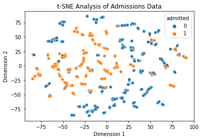

```python
sns.scatterplot(data=tsne_df, x='Dimension 1', y='Dimension 2', hue="admitted").set(
    title='t-SNE Analysis of Admissions Data', xlabel='Dimension 1', ylabel='Dimension 2')
```

From the graph above, we can see a loose cluster of admitted students (orange dots) towards the left of the graph before a dimension 1 value of 25.